# Practical Machine Learning. Final Project

## Background

Using devices such as Jawbone Up, Nike FuelBand, and Fitbit it is now possible to collect a large amount of data about personal activity relatively inexpensively. These type of devices are part of the quantified self movement – a group of enthusiasts who take measurements about themselves regularly to improve their health, to find patterns in their behavior, or because they are tech geeks. One thing that people regularly do is quantify how much of a particular activity they do, but they rarely quantify how well they do it. In this project, your goal will be to use data from accelerometers on the belt, forearm, arm, and dumbell of 6 participants. They were asked to perform barbell lifts correctly and incorrectly in 5 different ways. More information is available from the website here: http://groupware.les.inf.puc-rio.br/har (see the section on the Weight Lifting Exercise Dataset).

## Data

The training data for this project are available here:

https://d396qusza40orc.cloudfront.net/predmachlearn/pml-training.csv

The test data are available here:

https://d396qusza40orc.cloudfront.net/predmachlearn/pml-testing.csv

The data for this project come from this source: http://groupware.les.inf.puc-rio.br/har. If you use the document you create for this class for any purpose please cite them as they have been very generous in allowing their data to be used for this kind of assignment.

## Loading Libraries

```r
library(caret)
library(randomForest)
```

```r
library(rpart)
library(rattle) # Decision Tree drawing
training_data = read.csv("pml-training.csv")
testing_data  = read.csv("pml-testing.csv")

dim(training_data)
```

```
## [1] 19622   160
```

```r
#summary(subset(training_data, select = grep("_arm", colnames(training_data))))
levels(training_data$classe)
```

```
## [1] "A" "B" "C" "D" "E"
```

There are five classes in dataset, so it is a multiclassification problem.

### Delete columns with NA:

```r
training_data = training_data[, colSums(is.na(testing_data)) == 0]
testing_data  = testing_data[, colSums(is.na(testing_data)) == 0]
colnames(training_data)
```

```
##  [1] "X"                    "user_name"            "raw_timestamp_part_1"
##  [4] "raw_timestamp_part_2" "cvtd_timestamp"       "new_window"
##  [7] "num_window"           "roll_belt"            "pitch_belt"
## [10] "yaw_belt"             "total_accel_belt"     "gyros_belt_x"
## [13] "gyros_belt_y"         "gyros_belt_z"         "accel_belt_x"
## [16] "accel_belt_y"         "accel_belt_z"         "magnet_belt_x"
## [19] "magnet_belt_y"        "magnet_belt_z"        "roll_arm"
## [22] "pitch_arm"            "yaw_arm"              "total_accel_arm"
## [25] "gyros_arm_x"          "gyros_arm_y"          "gyros_arm_z"
## [28] "accel_arm_x"          "accel_arm_y"          "accel_arm_z"
## [31] "magnet_arm_x"         "magnet_arm_y"         "magnet_arm_z"
## [34] "roll_dumbbell"        "pitch_dumbbell"       "yaw_dumbbell"
## [37] "total_accel_dumbbell" "gyros_dumbbell_x"     "gyros_dumbbell_y"
## [40] "gyros_dumbbell_z"     "accel_dumbbell_x"     "accel_dumbbell_y"
## [43] "accel_dumbbell_z"     "magnet_dumbbell_x"    "magnet_dumbbell_y"
## [46] "magnet_dumbbell_z"    "roll_forearm"         "pitch_forearm"
## [49] "yaw_forearm"          "total_accel_forearm"  "gyros_forearm_x"
## [52] "gyros_forearm_y"      "gyros_forearm_z"      "accel_forearm_x"
## [55] "accel_forearm_y"      "accel_forearm_z"      "magnet_forearm_x"
## [58] "magnet_forearm_y"     "magnet_forearm_z"     "classe"
```

We could decompose our data through PCA.

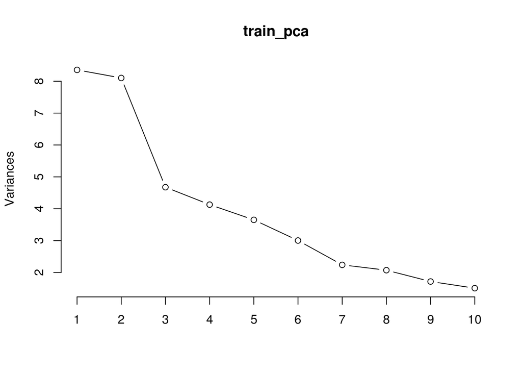

```r
# Get only numeric variables:
numeric = sapply(training_data, is.numeric)
training_data_num = training_data[, numeric]

# Imputting data:
for(i in 1:ncol(training_data_num)){
  training_data_num[is.na(training_data_num[,i]), i] <- median(training_data_num[,i], na.rm = TRUE)
}
train_pca = prcomp(training_data_num, center = TRUE, scale. = TRUE)
plot(train_pca, type='l')
```

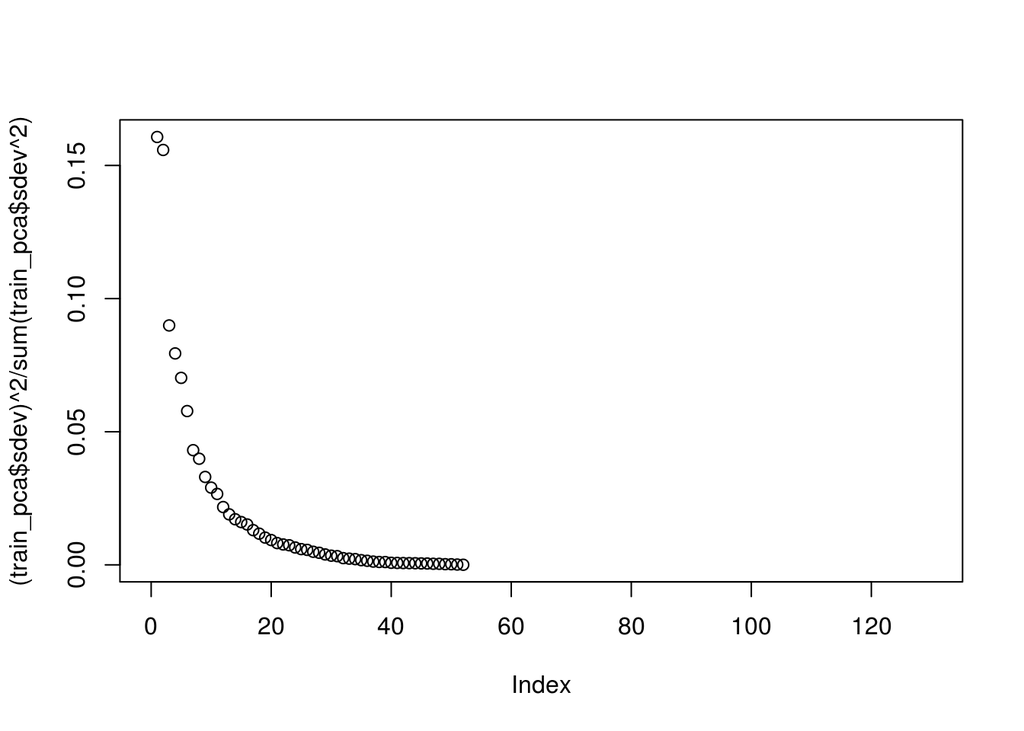

```r
plot((train_pca$sdev)^2 / sum(train_pca$sdev^2), xlim=c(0, 130))
```

### Create predictive models: Random Forest Calssifier and Decision Tree.

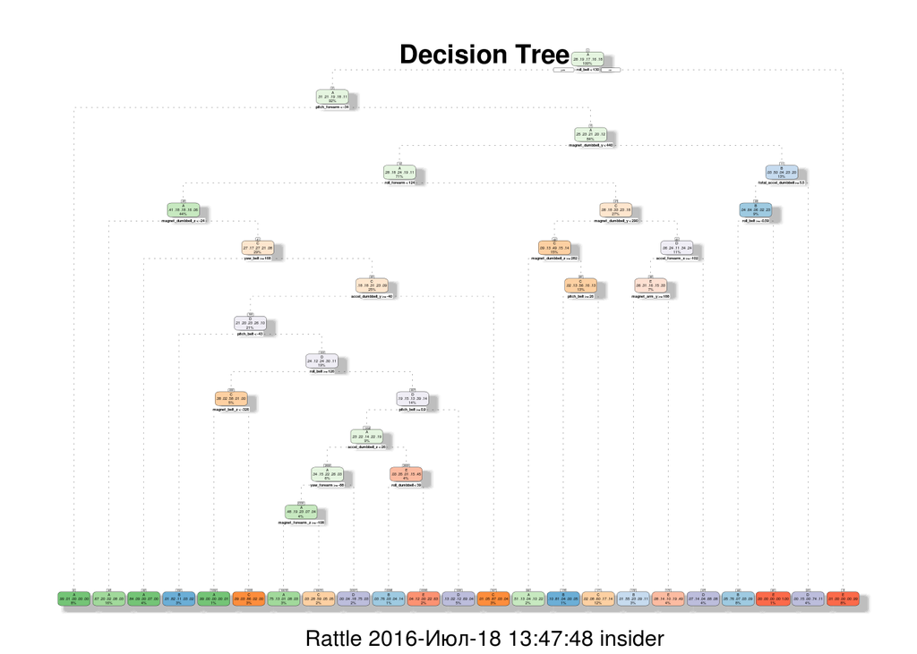

```r
# Random Forest
mod_rf  = randomForest(classe ~. , data = sub_training_data, method = "class")
pred_rf = predict(mod_rf, sub_testing_data, type = "class")
res_rf  = confusionMatrix(pred_rf, sub_testing_data$classe)

# Decision Tree
mod_dt  = rpart(classe ~ ., data = sub_training_data, method = "class")
pred_dt = predict(mod_dt, sub_testing_data, type = "class")
res_dt  = confusionMatrix(pred_dt, sub_testing_data$classe)
fancyRpartPlot(mod_dt, main='Decision Tree')
```

```r
res_dt$table
```

```
##           Reference
## Prediction    A    B    C    D    E
##          A 1512  252   38  125   63
##          B   44  681   93   35   69
##          C   41   86  818  135  103
##          D   53   67   48  601   49
##          E   24   53   29   68  798
```

```r
res_rf$table
```

```
##           Reference
## Prediction    A    B    C    D    E
##          A 1674    4    0    0    0
##          B    0 1135    8    0    0
##          C    0    0 1017    9    0
##          D    0    0    1  955    2
##          E    0    0    0    0 1080
```

Decision Tree has many splits, but doesn’t catch distinct differences between A/B, C/D, but predictions from Random Forest looks almost perfectly (see confusion matrixes).

```
##                res_rf.overall res_dt.overall
## Accuracy            0.9959218   7.493628e-01
## Kappa               0.9948410   6.808427e-01
## AccuracyLower       0.9939381   7.380834e-01
## AccuracyUpper       0.9973853   7.603944e-01
## AccuracyNull        0.2844520   2.844520e-01
## AccuracyPValue      0.0000000   0.000000e+00
## McnemarPValue             NaN   1.111594e-56
```

As we see, the Random Forest classifier has advantages over the Decision Tree. So we will use superior model:

### Final predictions for submitting:

```
##  1  2  3  4  5  6  7  8  9 10 11 12 13 14 15 16 17 18 19 20
##  B  A  B  A  A  E  D  B  A  A  B  C  B  A  E  E  A  B  B  B
## Levels: A B C D E
```